# Daily Mood Ratings and Analysis

Andrew McCartney

2024-04-26

# Introduction

to wit, Dailybean; thanks tiktok

e.g. gloomy, happy, etc

e.g. family, acquaintance, none

After about 120 days’ worth of ratings, I began to do deeper analyses on the data to track trends in mood.

which are almost all binary or essentially qualitative descriptions

Beginning in February 2024, I turned the analyses I was running into a daily report that contains ongoing analyses so that after I input last night’s data, I can get all of my typical questions re-calculated at the click of a button.

# Data

Pull the data from excel and display the first few days.

```
## # A tibble: 178 × 24
##    day        rating social_acquaintaince social_friend social_family
##    <date>      <dbl>                <dbl>         <dbl>         <dbl>
##  1 2023-10-12      3                    1             0             0
##  2 2023-10-13      2                    1             0             0
##  3 2023-10-14      4                    1             1             0
##  4 2023-10-15      3                    0             0             0
##  5 2023-10-16      3                    0             0             0
##  6 2023-10-17      1                    0             0             0
##  7 2023-10-18      3                    0             1             0
##  8 2023-10-19      2                    0             0             0
##  9 2023-10-20      3                    0             0             1
## 10 2023-10-21      3                    0             1             1
## # ℹ 168 more rows
## # ℹ 19 more variables: social_none <dbl>, weekday <dbl>, holiday <dbl>,
## #   feeling_excited <dbl>, feeling_relaxed <dbl>, feeling_proud <dbl>,
## #   feeling_hopeful <dbl>, feeling_happy <dbl>, feeling_enthusiastic <dbl>,
## #   `feeling_pit-a-pat` <dbl>, feeling_refreshed <dbl>, feeling_gloomy <dbl>,
## #   feeling_lonely <dbl>, feeling_anxious <dbl>, feeling_sad <dbl>,
## #   feeling_angry <dbl>, feeling_burdensome <dbl>, feeling_annoyed <dbl>, …
```

# Daily Mood Over Time

How has mood changed over time, in general? In this plot, I have also marked significant days and holidays as annotations; e.g. my trip to Colorado to see Katrina and Arielle as well as Valentines day, etc. The unmarked line at the end of January is my coffee date with Ashley. The unmarked line at the beginning of March is the anniversary of Laura’s text.

In a previous version of this graph I “jittered” the points to give it more liveliness, but the jitters were obscuring the actual values of the ratings more than I wanted and adjusting them by functional arguments didn’t solve the problem to my liking.

[figure not shown]

# Is there a cyclical effect?

As of February 2024, there appears to be a cyclical or sinusoidal pattern to my mood ratings. In this version of the plot, I have taken each month as a different factor and plotted its loess smoothed line, along with adding a grey line that indicates the loess smoothing of all of the months in the data set. There *does* appear to be a weak pattern of rise and fall peaking around the 10th of every month and falling around the 20th, but that’s probably just coincidences based on the fact that November and December both have holidays near the 20th of the month which depress scores.

More data are likely needed, at which point auto-regressive techniques might become necessary to determine real longterm patterns of growth.

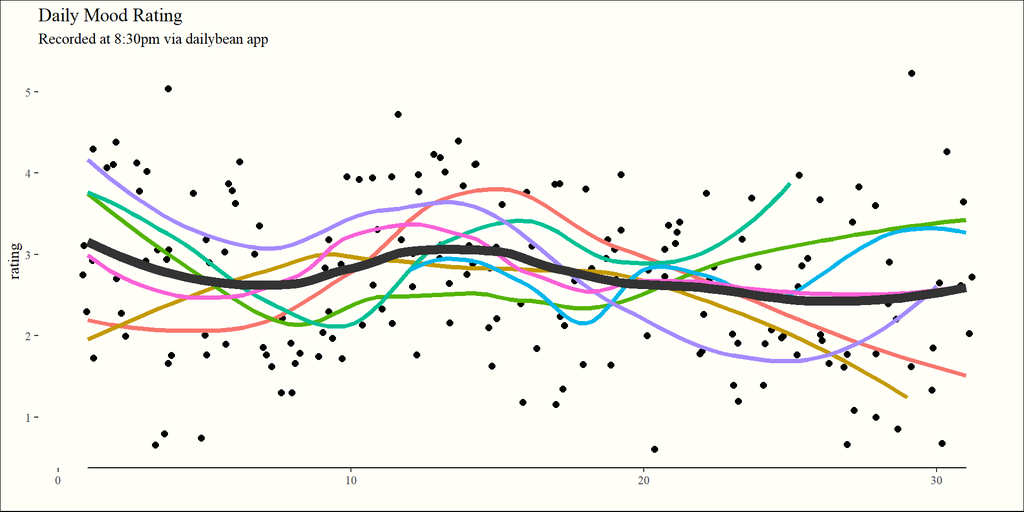

Update as of 3/19/24: Tess and I have discussed and the going theory is not that I have a depressive episode every time I ovulate–go figure. Instead, the current thesis is that when I start to feel too good I self sabotage or lean into wallowing/moping behaviors in order to justify the authenticity of my depression or “honor” my loss in some way by not allowing myself to be too happy. That this appears to happen on a monthly cycle is just a coincidence based on how long it takes me to kick a new depressive cycle.

or, for that matter, *kick off*

# Modeling

What can we learn from the data? Beware that linear modeling over these data is bound to be problematic given the aforementioned sinusoidal nature; however, even if there is no strong linear trend, controlling for time is probably still at least a little helpful. Other qualitative factors are included as listed.

## Data Description

Remember that the mean of a binary indicator is the % of the times the value is ‘true’

| Rowname | n | mean | sd | median | min | max | range | skew | kurtosis | se |
| --- | --- | --- | --- | --- | --- | --- | --- | --- | --- | --- |
| day | 178 | NaN | NA | NA | Inf | -Inf | -Inf | NA | NA | NA |
| rating | 177 | 2.73 | 0.97 | 3 | 1 | 5 | 4 | 0.0084405 | -0.7476768 | 0.07 |
| social_acquaintaince | 178 | 0.23 | 0.42 | 0 | 0 | 1 | 1 | 1.2701322 | -0.3888543 | 0.03 |
| social_friend | 178 | 0.26 | 0.44 | 0 | 0 | 1 | 1 | 1.0615113 | -0.8780321 | 0.03 |
| social_family | 178 | 0.16 | 0.37 | 0 | 0 | 1 | 1 | 1.8666594 | 1.4928989 | 0.03 |
| social_none | 178 | 0.45 | 0.50 | 0 | 0 | 1 | 1 | 0.2015786 | -1.9703409 | 0.04 |
| weekday | 178 | 3.96 | 2.03 | 4 | 1 | 7 | 6 | 0.0329648 | -1.2991524 | 0.15 |
| holiday | 178 | 0.04 | 0.21 | 0 | 0 | 1 | 1 | 4.3558755 | 17.0696426 | 0.02 |
| feeling_excited | 177 | 0.13 | 0.34 | 0 | 0 | 1 | 1 | 2.1825094 | 2.7791442 | 0.03 |
| feeling_relaxed | 177 | 0.18 | 0.38 | 0 | 0 | 1 | 1 | 1.6949218 | 0.8778149 | 0.03 |
| feeling_proud | 177 | 0.13 | 0.34 | 0 | 0 | 1 | 1 | 2.1825094 | 2.7791442 | 0.03 |
| feeling_hopeful | 177 | 0.18 | 0.39 | 0 | 0 | 1 | 1 | 1.6448585 | 0.7096646 | 0.03 |
| feeling_happy | 177 | 0.06 | 0.24 | 0 | 0 | 1 | 1 | 3.5965857 | 10.9976580 | 0.02 |
| feeling_enthusiastic | 177 | 0.06 | 0.24 | 0 | 0 | 1 | 1 | 3.5965857 | 10.9976580 | 0.02 |
| feeling_pit-a-pat | 177 | 0.05 | 0.22 | 0 | 0 | 1 | 1 | 4.0544349 | 14.5205750 | 0.02 |
| feeling_refreshed | 177 | 0.12 | 0.32 | 0 | 0 | 1 | 1 | 2.3386807 | 3.4892360 | 0.02 |
| feeling_gloomy | 177 | 0.21 | 0.41 | 0 | 0 | 1 | 1 | 1.4189969 | 0.0137253 | 0.03 |
| feeling_lonely | 177 | 0.19 | 0.40 | 0 | 0 | 1 | 1 | 1.5499872 | 0.4048433 | 0.03 |
| feeling_anxious | 177 | 0.60 | 0.49 | 1 | 0 | 1 | 1 | -0.4000323 | -1.8503325 | 0.04 |
| feeling_sad | 177 | 0.31 | 0.46 | 0 | 0 | 1 | 1 | 0.8394769 | -1.3025419 | 0.03 |
| feeling_angry | 177 | 0.16 | 0.37 | 0 | 0 | 1 | 1 | 1.8574722 | 1.4585389 | 0.03 |
| feeling_burdensome | 177 | 0.10 | 0.30 | 0 | 0 | 1 | 1 | 2.7186962 | 5.4220378 | 0.02 |
| feeling_annoyed | 177 | 0.24 | 0.43 | 0 | 0 | 1 | 1 | 1.2246177 | -0.5030581 | 0.03 |
| feeling_tired | 177 | 0.35 | 0.48 | 0 | 0 | 1 | 1 | 0.6223579 | -1.6217374 | 0.04 |

## Relationships

First, controlling for any effect of time (date), is mood better on days when I am with certain groups, to wit family, friends, acquaintances? The reference group is “none” days where I don’t socialize with anyone. A work day is considered a “none” day unless I socialize with coworkers outside of work. Holidays are included as a control since they are strongly associated in the data with negative ratings.

e.g. a happy hour

i.e., what is the effect of being around my family while controlling for the effect of it being on a holiday?

|  | rating |  |  | rating |  |  |
| --- | --- | --- | --- | --- | --- | --- |
| Predictors | Estimates | CI | p | Estimates | CI | p |
| (Intercept) | -3.04 | -50.90 – 44.82 | 0.900 | -2.97 | -50.79 – 44.85 | 0.903 |
| day | 0.00 | -0.00 – 0.00 | 0.820 | 0.00 | -0.00 – 0.00 | 0.822 |
| holiday | -0.26 | -0.74 – 0.22 | 0.292 |  |  |  |
| social acquaintaince | 0.35 | -0.01 – 0.70 | 0.056 | 0.34 | -0.01 – 0.70 | 0.057 |
| social friend | 0.70 | 0.36 – 1.04 | **<0.001** | 0.69 | 0.35 – 1.02 | **<0.001** |
| social family | -0.14 | -0.46 – 0.19 | 0.408 | -0.15 | -0.48 – 0.17 | 0.354 |
| Observations | 177 |  |  | 177 |  |  |
| R<sup>2</sup> / R<sup>2</sup> adjusted | 0.121 / 0.095 |  |  | 0.118 / 0.097 |  |  |

## Weekday

|  | rating |  |  |
| --- | --- | --- | --- |
| Predictors | Estimates | CI | p |
| (Intercept) | 2.79 | 2.41 – 3.16 | **<0.001** |
| weekday2 | -0.32 | -0.83 – 0.19 | 0.222 |
| weekday3 | -0.05 | -0.61 – 0.51 | 0.855 |
| weekday4 | 0.04 | -0.47 – 0.56 | 0.868 |
| weekday5 | -0.07 | -0.60 – 0.45 | 0.780 |
| weekday6 | -0.15 | -0.70 – 0.41 | 0.605 |
| weekday7 | 0.18 | -0.37 – 0.73 | 0.528 |
| holiday | -0.07 | -0.76 – 0.62 | 0.840 |
| Observations | 177 |  |  |
| R<sup>2</sup> / R<sup>2</sup> adjusted | 0.023 / -0.018 |  |  |

But I suppose if we wanted, we could, say, recode Saturday and Sunday into a binary indicator for weekend and see what the result is, though it’ll be unbalanced in a 5:2 ratio

and see later where the holiday variable is completely unbalanced.

|  | rating |  |  |
| --- | --- | --- | --- |
| Predictors | Estimates | CI | p |
| (Intercept) | 2.67 | 2.50 – 2.84 | **<0.001** |
| weekend | 0.20 | -0.12 – 0.52 | 0.217 |
| Observations | 177 |  |  |
| R<sup>2</sup> / R<sup>2</sup> adjusted | 0.009 / 0.003 |  |  |

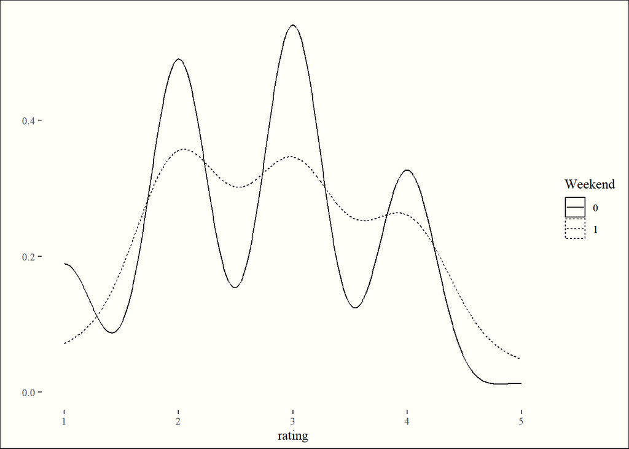

I *am* concerned about the balance of the variables, however, so let’s perform Levene’s Test just to make sure we’re in the clear with homogeneity of variances.

|  | Df | F value | Pr(>F) |
| --- | --- | --- | --- |
| group | 1 | 0.0067508 | 0.9346109 |
|  | 175 | NA | NA |

Okay. Resting easier in that regard.

The implicit hypothesis of this one would be that part of the impact of weekends and friends both being predictors of a better day is that they overlap in some way. This model disentangles that a little bit given that I have plenty of weekends that don’t contain friend and plenty of friend that happens on weekdays.

|  | rating |  |  |
| --- | --- | --- | --- |
| Predictors | Estimates | CI | p |
| (Intercept) | 2.53 | 2.34 – 2.71 | **<0.001** |
| weekend | 0.12 | -0.25 – 0.49 | 0.527 |
| social friend | 0.71 | 0.31 – 1.12 | **0.001** |
| weekend × social friend | -0.18 | -0.85 – 0.49 | 0.602 |
| Observations | 177 |  |  |
| R<sup>2</sup> / R<sup>2</sup> adjusted | 0.092 / 0.076 |  |  |

It *looks* like the benefit of it being a weekend is entirely accounted for by the fact that I sometimes see friends on weekends, and if we partial out the benefit of friendship, the benefit of weekend alone is entirely explained. So to conclude, the only good things about weekends for me are that sometimes I hang with friends on them.

and, interestingly, the benefit of seeing friends ON a weekend!!!

By the way, this 2x2 binary structure has the feeling of a Diff-in-Diff, weirdly, so we could recompose this as just a table of means to make the regression sligthtly easier to interpret, now that we know which one is statistically significant:

| weekend | social_friend | mu | sigma |
| --- | --- | --- | --- |
| no | no | 2.53 | 0.93 |
| no | yes | 3.24 | 0.93 |
| yes | no | 2.65 | 0.91 |
| yes | yes | 3.18 | 1.01 |

# Emotions

What are my most common feelings? How often do I rate a day as having contained that emotion?

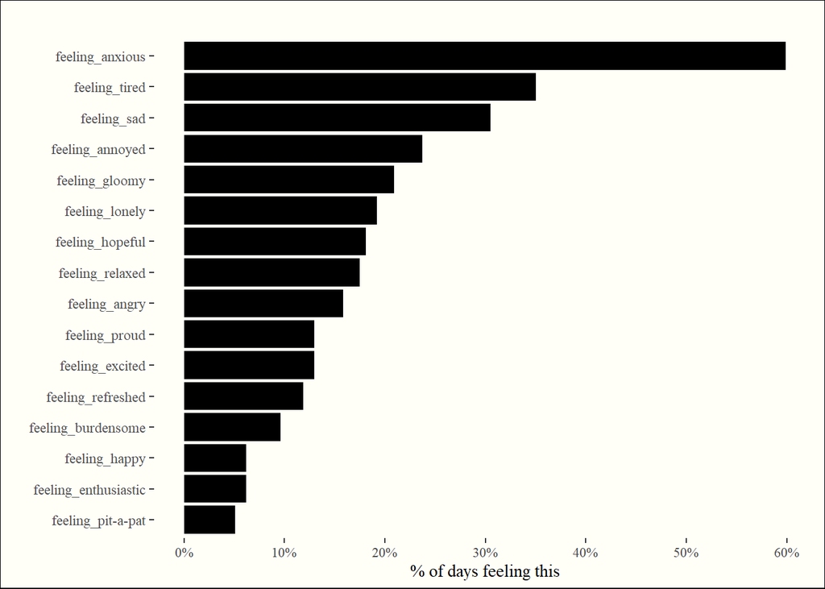

Well, as a multiple regression but when it’s only 6 qualitative factors we’re really talking about an ANOVA with the posthoc test built in, which is why we regress. yesssss.

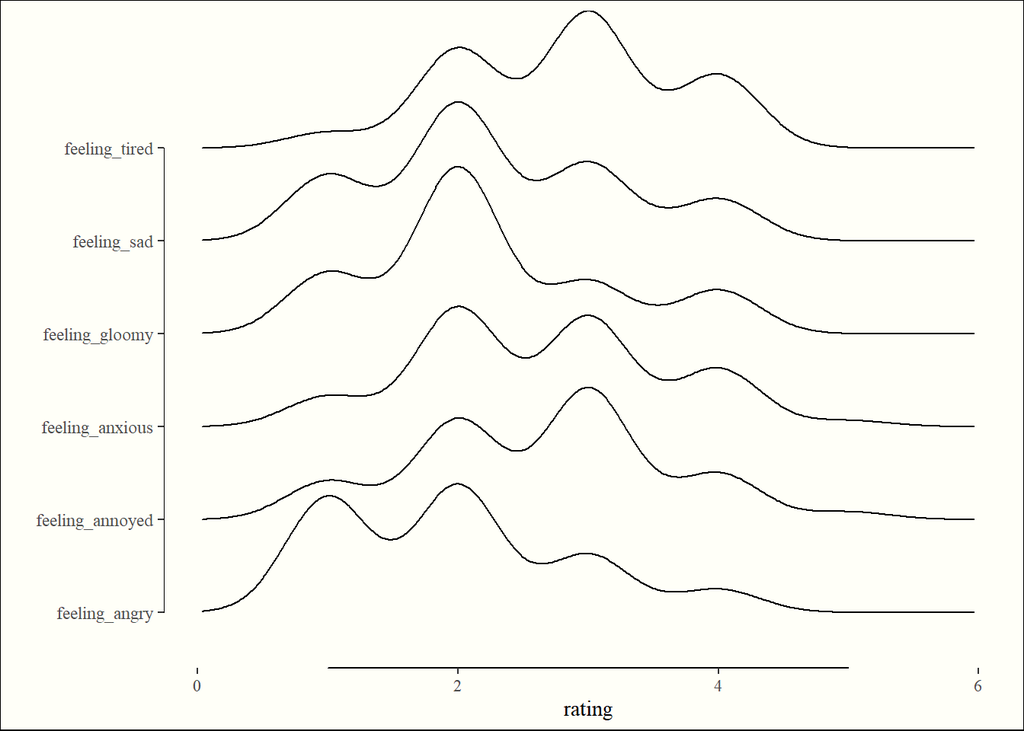

## modeling emotions

|  | rating |  |  | rating |  |  |
| --- | --- | --- | --- | --- | --- | --- |
| Predictors | Estimates | CI | p | Estimates | CI | p |
| (Intercept) | 3.08 | 2.84 – 3.31 | **<0.001** | -13.09 | -60.76 – 34.59 | 0.589 |
| feeling anxious | -0.05 | -0.33 – 0.22 | 0.704 | -0.07 | -0.36 – 0.22 | 0.632 |
| feeling tired | 0.07 | -0.19 – 0.34 | 0.596 | 0.06 | -0.21 – 0.33 | 0.654 |
| feeling sad | -0.50 | -0.81 – -0.19 | **0.002** | -0.52 | -0.82 – -0.21 | **0.001** |
| feeling gloomy | -0.43 | -0.78 – -0.07 | **0.018** | -0.42 | -0.77 – -0.07 | **0.018** |
| feeling annoyed | 0.08 | -0.24 – 0.41 | 0.609 | 0.07 | -0.26 – 0.40 | 0.678 |
| feeling angry | -0.75 | -1.18 – -0.31 | **0.001** | -0.74 | -1.18 – -0.30 | **0.001** |
| day |  |  |  | 0.00 | -0.00 – 0.00 | 0.504 |
| Observations | 177 |  |  | 177 |  |  |
| R<sup>2</sup> / R<sup>2</sup> adjusted | 0.215 / 0.187 |  |  | 0.217 / 0.184 |  |  |

## Emotions as networks

One analytic tool for thinking about how my emotions work is to ask what kinds of emotions occur *together*. For example, some days are really packed with lots of emotions:

| day | total_emotions |
| --- | --- |
| 2024-03-31 | 10 |
| 2024-04-12 | 9 |
| 2024-03-03 | 8 |
| 2024-04-02 | 8 |
| 2024-04-09 | 8 |
| 2023-12-01 | 7 |

So there are two main data visualizations that I think might be helpful to take a look at this, the first being a heatmap that gives us a general idea of which co-occurring emotions happen the most:

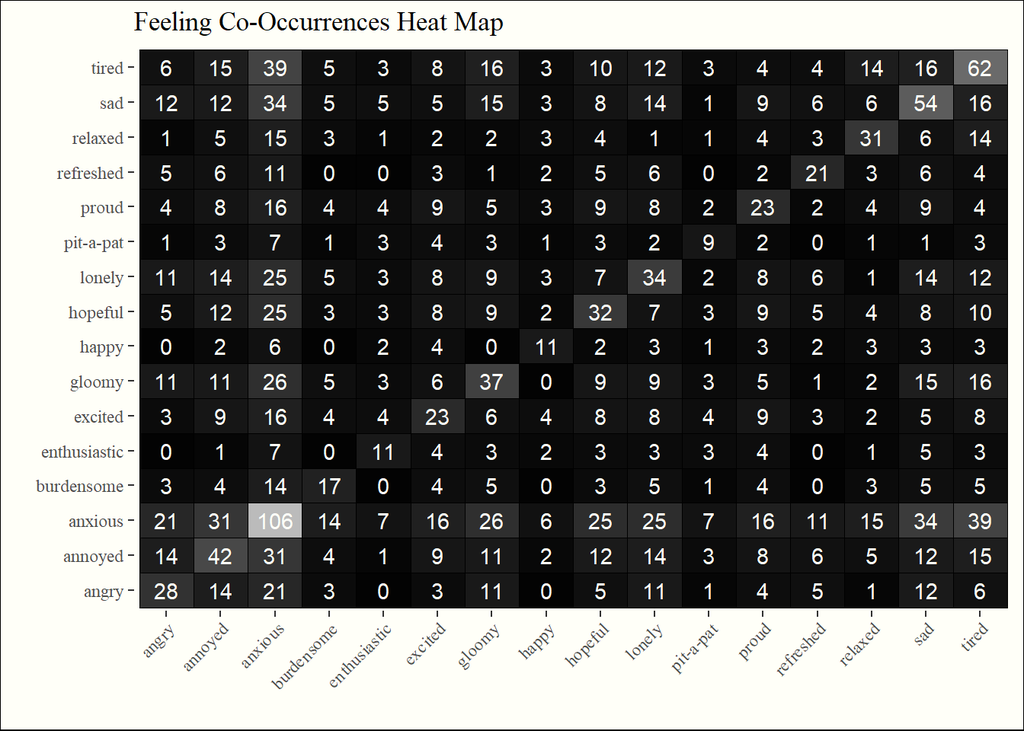

But perhaps a better way to think about it, and one which has less of the problem of “anxious plus anxious” being such a big thing, would be to do an edge bundle where every emotion is a node and you can see how often it connects with other emotion nodes by the strength of that connection:

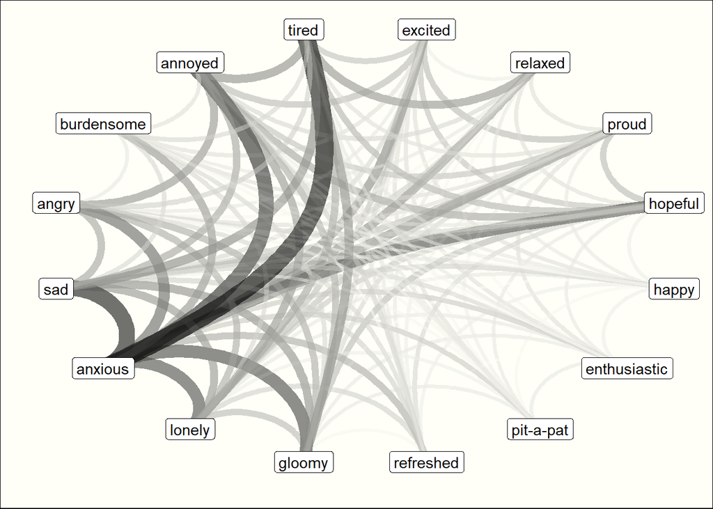

Here we still see the importance of anxiety as my most common emotion, but it also really lets you explore the strength of other relationships. The next big thing on this notion of co-occurring emotions would be to use clustering algorithms or dimension reduction, which I have worked on but not gotten to a point where I feel that it’s worth trying to publish to this document.

# The holiday effect

I lied before when I said holidays were strongly negatively associated with lower mood. This is an artifact in the data due to really bad times around Thanksgiving and Christmas. A t-test can be used to determine this effect. However, the t-test is so unbalanced that the standard errors get blown to all hell and it’s worse than worthless. Some holidays suck, some holidays are anodyne. Nevertheless, I’m going to keep it as a control for other models.

| holiday | number |
| --- | --- |
| no | 170 |
| yes | 8 |

As you can see, we are incredibly unbalanced, but for kicks:

|  | rating |  |  |
| --- | --- | --- | --- |
| Predictors | Estimates | CI | p |
| (Intercept) | 2.73 | 2.59 – 2.88 | **<0.001** |
| holiday | -0.11 | -0.77 – 0.55 | 0.744 |
| Observations | 177 |  |  |
| R<sup>2</sup> / R<sup>2</sup> adjusted | 0.001 / -0.005 |  |  |